# Modelos de MP por area

# Estimacion del Area a partir de la Biomasa

La función estima el area foliar por especie a partir del valor de Biomasa [gramos]
$$Area=a+b\cdot Biomasa$$

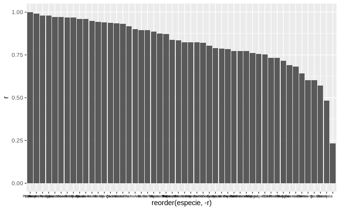

```r
# Regresion Area por especie
modelArea <- by(dataAreas,dataAreas$Especie, function (df) lm(Area ~ Biomasa_g, data = df))
Rcuadrado <- lapply(rownames(modelArea), function (especie) summary(modelArea[[especie]])$r.squared)

pAreas <-ggplot(data=data.frame(especie=rownames(modelArea), r=unlist(Rcuadrado)),
           aes(x=reorder(especie,-r), y=r)) + geom_bar(stat="identity")


# Recorte de Outliers
significancia = .95
recorte <- function (df) {
  distances = mahalanobis(df[,5:6],colMeans(df[,5:6]),cov(df[,5:6]))
  cutoff =quantile(distances, significancia)
  outliers = df[distances < cutoff,]
  return(outliers)
}
dataAreasclean <- by(dataAreas, dataAreas$Especie, function(df) recorte(df))
modelArea <- lapply(rownames(dataAreasclean), function (especie)
                        lm(Area ~ Biomasa_g,
                        data = dataAreasclean[[especie]]))
Rcuadrado   <- lapply(modelArea, function (df) summary(df)$r.squared)
coefficientsArea<- lapply(modelArea, function (df) summary(df)$coefficients)
pAreasclean <-ggplot(data=data.frame(especie=rownames(dataAreasclean), r=unlist(Rcuadrado)),
                  aes(x=reorder(especie,-r), y=r)) + geom_bar(stat="identity")+theme(axis.text.x = element_text(size = 5, hjust = 1, family = "Helvetica",colour="black"))
pAreasclean
```

```r
summary(Area)
```

```
    Min.  1st Qu.   Median     Mean  3rd Qu.     Max.
   1.982   34.531  120.730  179.359  245.306 1459.422
```

Prediccion de area foliar por individuo desde la estimacion de biomasa foliar. Es de notar que hay 4 arboles para los que no se tiene un modelo de area foliar por biomasa por lo que esas especies no tienen prediccion, almenos de momento

```r
modelArea <- setNames(modelArea,rownames(dataAreasclean))

predict_vals <- function(df){
  species <- unique(df$Nombre.común)
  #print(species)

  if (!is.null(modelArea[[species]])){
    df$pred_area <- predict.lm(modelArea[[species]],df)
    return(df)
  }else{
    print("not_area")
  }
  #df$pred_area <- predict.lm(test[[species]],df)
  #return(df)
}

predicted_area <- by(dataDiametros, dataDiametros$Nombre.común, function(df) predict_vals(df))
```

```
[1] "not_area"
[1] "not_area"
[1] "not_area"
[1] "not_area"
```

```r
## Toca que "modelArea" este definido globalmente y que tenga indexado los nombres la especie correspondiente
```

```r
to_eliminate <- c(62)

MP2.5 <- lm(log(Material_2.5) ~ log(Area) + Tipo_Hoja, data=dataDiametros)#[-to_eliminate,]
anova(MP2.5)
```

```
Analysis of Variance Table

Response: log(Material_2.5)
           Df Sum Sq Mean Sq F value    Pr(>F)
log(Area)   1 39.155  39.155 96.1650 < 2.2e-16 ***
Tipo_Hoja   9 19.635   2.182  5.3582 1.269e-06 ***
Residuals 218 88.761   0.407
---
Signif. codes:  0 ‘***’ 0.001 ‘**’ 0.01 ‘*’ 0.05 ‘.’ 0.1 ‘ ’ 1
```

```r
bptest(MP2.5)
```

```
    studentized Breusch-Pagan test

data:  MP2.5
BP = 17.891, df = 10, p-value = 0.05683
```

```r
gvlma(MP2.5)
```

```
Call:
lm(formula = log(Material_2.5) ~ log(Area) + Tipo_Hoja, data = dataDiametros)

Coefficients:
                       (Intercept)                           log(Area)                 Tipo_Hoja4_foliolos
                          -4.55129                             0.23152                            -0.17154
       Tipo_HojaCompuesta_bipinada    Tipo_HojaCompuesta_imparipinnada                   Tipo_HojaDigitada
                          -0.85583                            -1.40885                            -0.49086
Tipo_HojaHiper_grande_formas_raras    Tipo_HojaParipinnada_tallo_hojas                     Tipo_HojaSimple
                          -0.01506                            -0.31465                            -0.77220
            Tipo_HojaSimple_grande             Tipo_HojaSimple_pequeña
                          -0.82801                            -0.71038


ASSESSMENT OF THE LINEAR MODEL ASSUMPTIONS
USING THE GLOBAL TEST ON 4 DEGREES-OF-FREEDOM:
Level of Significance =  0.05

Call:
 gvlma(x = MP2.5)
```

|  | Value | p-value | Decision |
| --- | --- | --- | --- |
| Global Stat | 6.9329961 | 0.1394717 | Assumptions acceptable. |
| Skewness | 2.4733582 | 0.1157903 | Assumptions acceptable. |
| Kurtosis | 2.0230369 | 0.1549290 | Assumptions acceptable. |
| Link Function | 0.8807897 | 0.3479855 | Assumptions acceptable. |
| Heteroscedasticity | 1.5558113 | 0.2122796 | Assumptions acceptable. |

```r
shapiro.test(MP2.5$residuals)
```

```
    Shapiro-Wilk normality test

data:  MP2.5$residuals
W = 0.99002, p-value = 0.1158
```

```r
summary(MP2.5)
```

```
Call:
lm(formula = log(Material_2.5) ~ log(Area) + Tipo_Hoja, data = dataDiametros)

Residuals:
     Min       1Q   Median       3Q      Max
-1.89448 -0.42121 -0.03033  0.38389  2.09633

Coefficients:
                                   Estimate Std. Error t value Pr(>|t|)
(Intercept)                        -4.55129    0.40685 -11.187  < 2e-16 ***
log(Area)                           0.23152    0.04774   4.850 2.35e-06 ***
Tipo_Hoja4_foliolos                -0.17154    0.48260  -0.355   0.7226
Tipo_HojaCompuesta_bipinada        -0.85583    0.18447  -4.639 6.03e-06 ***
Tipo_HojaCompuesta_imparipinnada   -1.40885    0.24252  -5.809 2.21e-08 ***
Tipo_HojaDigitada                  -0.49086    0.22049  -2.226   0.0270 *
Tipo_HojaHiper_grande_formas_raras -0.01506    0.35138  -0.043   0.9658
Tipo_HojaParipinnada_tallo_hojas   -0.31465    0.20011  -1.572   0.1173
Tipo_HojaSimple                    -0.77220    0.17361  -4.448 1.38e-05 ***
Tipo_HojaSimple_grande             -0.82801    0.20816  -3.978 9.47e-05 ***
Tipo_HojaSimple_pequeña            -0.71038    0.24065  -2.952   0.0035 **
---
Signif. codes:  0 ‘***’ 0.001 ‘**’ 0.01 ‘*’ 0.05 ‘.’ 0.1 ‘ ’ 1

Residual standard error: 0.6381 on 218 degrees of freedom
  (26 observations deleted due to missingness)
Multiple R-squared:  0.3984,    Adjusted R-squared:  0.3708
F-statistic: 14.44 on 10 and 218 DF,  p-value: < 2.2e-16
```

```r
# if bptest not enough
reg <-cochrane.orcutt(MP2.5)
summary(reg)
```

```
Call:
lm(formula = log(Material_2.5) ~ log(Area) + Tipo_Hoja, data = dataDiametros)

                                    Estimate Std. Error t value  Pr(>|t|)
(Intercept)                        -4.228350   0.471542  -8.967 < 2.2e-16 ***
log(Area)                           0.190698   0.054926   3.472 0.0006236 ***
Tipo_Hoja4_foliolos                -0.289357   0.527587  -0.548 0.5839452
Tipo_HojaCompuesta_bipinada        -0.882245   0.224773  -3.925 0.0001164 ***
Tipo_HojaCompuesta_imparipinnada   -1.506628   0.296870  -5.075 8.316e-07 ***
Tipo_HojaDigitada                  -0.456359   0.273096  -1.671 0.0961513 .
Tipo_HojaHiper_grande_formas_raras  0.334731   0.387609   0.864 0.3887738
Tipo_HojaParipinnada_tallo_hojas   -0.303858   0.239151  -1.271 0.2052427
Tipo_HojaSimple                    -0.808110   0.206379  -3.916 0.0001207 ***
Tipo_HojaSimple_grande             -0.900086   0.245645  -3.664 0.0003119 ***
Tipo_HojaSimple_pequeña            -0.816278   0.286355  -2.851 0.0047847 **
---
Signif. codes:  0 ‘***’ 0.001 ‘**’ 0.01 ‘*’ 0.05 ‘.’ 0.1 ‘ ’ 1

Residual standard error: 0.6033 on 225 degrees of freedom
Multiple R-squared:  0.3198 ,  Adjusted R-squared:  0.3137
F-statistic: 10.2 on 2 and 225 DF,  p-value: < 4.98e-14

Durbin-Watson statistic
(original):    1.48108 , p-value: 4.323e-06
(transformed): 2.04722 , p-value: 4.89e-01
```

```r
bptest(reg)
```

```
    studentized Breusch-Pagan test

data:  reg
BP = 11.816, df = 10, p-value = 0.2975
```

```r
bptest(reg)
```

```
    studentized Breusch-Pagan test

data:  reg
BP = 11.816, df = 10, p-value = 0.2975
```

```r
shapiro.test(reg$residuals)
```

```
    Shapiro-Wilk normality test

data:  reg$residuals
W = 0.98955, p-value = 0.09653
```

```r
modelo_10 <- lm(log(Material_10) ~ log(Area) + Tipo_Hoja,data=dataDiametros[-c(62),])#[-c(32,61,62,168,242),])

summary(modelo_10)
```

```
Call:
lm(formula = log(Material_10) ~ log(Area) + Tipo_Hoja, data = dataDiametros[-c(62),
    ])

Residuals:
     Min       1Q   Median       3Q      Max
-1.78772 -0.54501 -0.09681  0.46372  2.19875

Coefficients:
                                   Estimate Std. Error t value Pr(>|t|)
(Intercept)                        -4.19373    0.49522  -8.468 3.76e-15 ***
log(Area)                           0.32882    0.05818   5.652 4.96e-08 ***
Tipo_Hoja4_foliolos                -2.09391    0.58285  -3.593 0.000405 ***
Tipo_HojaCompuesta_bipinada        -1.38842    0.22286  -6.230 2.39e-09 ***
Tipo_HojaCompuesta_imparipinnada   -1.74717    0.29297  -5.964 9.91e-09 ***
Tipo_HojaDigitada                  -0.42428    0.26621  -1.594 0.112436
Tipo_HojaHiper_grande_formas_raras  0.05234    0.42425   0.123 0.901924
Tipo_HojaParipinnada_tallo_hojas   -0.49732    0.24482  -2.031 0.043437 *
Tipo_HojaSimple                    -0.91739    0.20981  -4.372 1.91e-05 ***
Tipo_HojaSimple_grande             -0.58670    0.25141  -2.334 0.020530 *
Tipo_HojaSimple_pequeña            -1.38054    0.29136  -4.738 3.90e-06 ***
---
Signif. codes:  0 ‘***’ 0.001 ‘**’ 0.01 ‘*’ 0.05 ‘.’ 0.1 ‘ ’ 1

Residual standard error: 0.7704 on 217 degrees of freedom
  (26 observations deleted due to missingness)
Multiple R-squared:  0.5142,    Adjusted R-squared:  0.4919
F-statistic: 22.97 on 10 and 217 DF,  p-value: < 2.2e-16
```

```r
nonparmod10 <- aov(log(Material_10) ~ log(Area) + factor(Tipo_Hoja),data=dataDiametros[-c(62),])
summary(nonparmod10)
```

```
                   Df Sum Sq Mean Sq F value   Pr(>F)
log(Area)           1  96.04   96.04 161.822  < 2e-16 ***
factor(Tipo_Hoja)   9  40.30    4.48   7.545 1.34e-09 ***
Residuals         217 128.79    0.59
---
Signif. codes:  0 ‘***’ 0.001 ‘**’ 0.01 ‘*’ 0.05 ‘.’ 0.1 ‘ ’ 1
26 observations deleted due to missingness
```

```r
anova(modelo_10)
```

```
Analysis of Variance Table

Response: log(Material_10)
           Df  Sum Sq Mean Sq  F value    Pr(>F)
log(Area)   1  96.043  96.043 161.8223 < 2.2e-16 ***
Tipo_Hoja   9  40.303   4.478   7.5451 1.336e-09 ***
Residuals 217 128.792   0.594
---
Signif. codes:  0 ‘***’ 0.001 ‘**’ 0.01 ‘*’ 0.05 ‘.’ 0.1 ‘ ’ 1
```

```r
gvlma(modelo_10)
```

```
Call:
lm(formula = log(Material_10) ~ log(Area) + Tipo_Hoja, data = dataDiametros[-c(62),
    ])

Coefficients:
                       (Intercept)                           log(Area)                 Tipo_Hoja4_foliolos
                          -4.19373                             0.32882                            -2.09391
       Tipo_HojaCompuesta_bipinada    Tipo_HojaCompuesta_imparipinnada                   Tipo_HojaDigitada
                          -1.38842                            -1.74717                            -0.42428
Tipo_HojaHiper_grande_formas_raras    Tipo_HojaParipinnada_tallo_hojas                     Tipo_HojaSimple
                           0.05234                            -0.49732                            -0.91739
            Tipo_HojaSimple_grande             Tipo_HojaSimple_pequeña
                          -0.58670                            -1.38054


ASSESSMENT OF THE LINEAR MODEL ASSUMPTIONS
USING THE GLOBAL TEST ON 4 DEGREES-OF-FREEDOM:
Level of Significance =  0.05

Call:
 gvlma(x = modelo_10)
```

|  | Value | p-value | Decision |
| --- | --- | --- | --- |
| Global Stat | 25.88558263 | 3.337082e-05 | Assumptions NOT satisfied! |
| Skewness | 9.70988918 | 1.832791e-03 | Assumptions NOT satisfied! |
| Kurtosis | 0.04638045 | 8.294857e-01 | Assumptions acceptable. |
| Link Function | 13.52955345 | 2.348359e-04 | Assumptions NOT satisfied! |
| Heteroscedasticity | 2.59975955 | 1.068799e-01 | Assumptions acceptable. |

```r
shapiro.test(nonparmod10$residuals)
```

```
    Shapiro-Wilk normality test

data:  nonparmod10$residuals
W = 0.97884, p-value = 0.001709
```

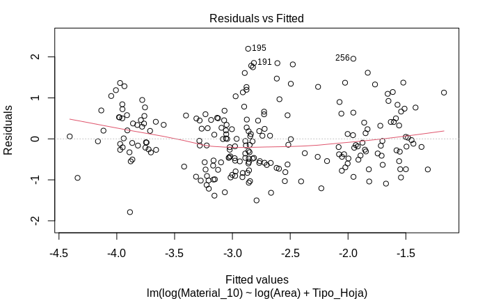

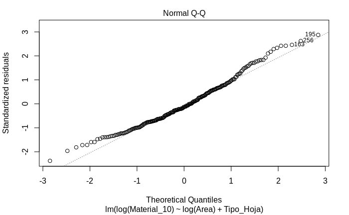

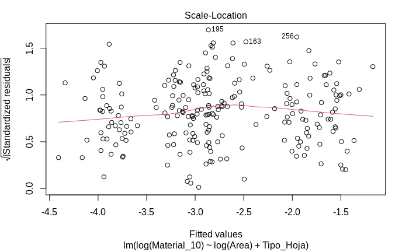

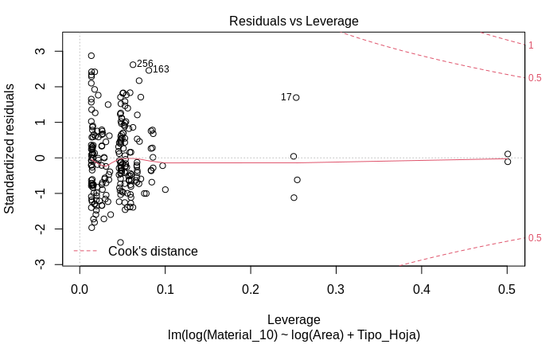

```r
plot(modelo_10)
```

```r
#gvlma(modelo_10)
shapiro.test(modelo_10$residuals)
```

```
    Shapiro-Wilk normality test

data:  modelo_10$residuals
W = 0.97884, p-value = 0.001709
```

```r
bptest(modelo_10)
```

```
    studentized Breusch-Pagan test

data:  modelo_10
BP = 12.429, df = 10, p-value = 0.2573
```

```r
dataDiametros <- dataDiametros[!is.na(dataDiametros$Area),]
#Tests no requieren de supuestos
kruskal.test(log(Material_10) ~  Tipo_Hoja, data=dataDiametros[-c(62),])
```

```
    Kruskal-Wallis rank sum test

data:  log(Material_10) by Tipo_Hoja
Kruskal-Wallis chi-squared = 102.07, df = 9, p-value < 2.2e-16
```

```r
wilcox.test( log(Area), log(Material_10), alternative = "two.sided")
```

```
    Wilcoxon rank sum test with continuity correction

data:  log(Area) and log(Material_10)
W = 184110, p-value < 2.2e-16
alternative hypothesis: true location shift is not equal to 0
```

```r
## tests without log that don't require assumptions
kruskal.test(Material_10 ~  Tipo_Hoja, data=dataDiametros[-c(62),])
```

```
    Kruskal-Wallis rank sum test

data:  Material_10 by Tipo_Hoja
Kruskal-Wallis chi-squared = 102.07, df = 9, p-value < 2.2e-16
```

```r
wilcox.test( Area, Material_10, alternative = "two.sided")
```

```
    Wilcoxon rank sum test with continuity correction

data:  Area and Material_10
W = 184110, p-value < 2.2e-16
alternative hypothesis: true location shift is not equal to 0
```

```r
#########IF the coeficients are not right and ther is another way this is a try
# this packages are used to find the best distribution that fits the data(the y distribution? or residuals)
library(gamlss)
library(gamlss.dist)
library(gamlss.add)
modelo_10$residuals <- modelo_10$residuals[!is.na(modelo_10$residuals)]
fit <- fitDist(modelo_10$residuals)
```

[output not shown]

[output not shown]

[output not shown]

[output not shown]

```r
summary(fit)
```

```
Family:  c("SN2", "skew normal type 2")

Call:  gamlssML(formula = y, family = DIST[i])

Fitting method: "nlminb"


Coefficient(s):
            Estimate  Std. Error  t value   Pr(>|t|)
eta.mu    -0.4322421   0.1094313 -3.94990 7.8185e-05 ***
eta.sigma -0.3898907   0.0600767 -6.48988 8.5902e-11 ***
eta.nu     0.3898821   0.1013656  3.84630 0.00011992 ***
---
Signif. codes:  0 ‘***’ 0.001 ‘**’ 0.01 ‘*’ 0.05 ‘.’ 0.1 ‘ ’ 1

 Degrees of Freedom for the fit: 3 Residual Deg. of Freedom   225
Global Deviance:     503.06
            AIC:     509.06
            SBC:     519.348
```

```r
dataDiametros <- dataDiametros[!is.na(dataDiametros$Material_10),]
fit <- fitDist(dataDiametros$Material_10,try.gamlss = TRUE)
summary(fit)
```

```
Family:  c("SEP4", "skew exponential power type 4")

Call:  gamlssML(formula = y, family = DIST[i])

Fitting method: "nlminb"


Coefficient(s):
             Estimate  Std. Error   t value   Pr(>|t|)
eta.mu     0.03593548  0.00159604  22.51542 < 2.22e-16 ***
eta.sigma -3.58307134  0.08962840 -39.97697 < 2.22e-16 ***
eta.nu     1.70245739  0.27168699   6.26625 3.6986e-10 ***
eta.tau   -0.63174032  0.03551999 -17.78549 < 2.22e-16 ***
---
Signif. codes:  0 ‘***’ 0.001 ‘**’ 0.01 ‘*’ 0.05 ‘.’ 0.1 ‘ ’ 1

 Degrees of Freedom for the fit: 4 Residual Deg. of Freedom   225
Global Deviance:     -595.973
            AIC:     -587.973
            SBC:     -574.238
```

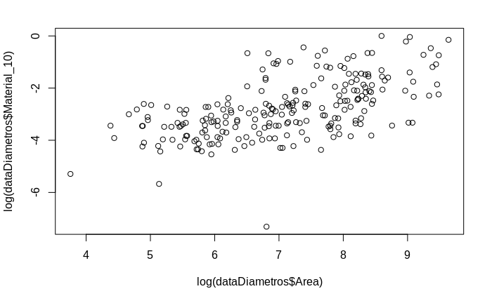

```r
#"skew exponential power type 4    mu.link = "identity", sigma.link = "log", nu.link = "log", tau.link = "log"

dataDiametros <- dataDiametros[!is.na(dataDiametros$Area),]
plot(log(dataDiametros$Area),log(dataDiametros$Material_10))
```

```r
regglm <- glm(log(Material_10) ~ log(Area) + factor(Tipo_Hoja), data=dataDiametros, family=gaussian)
summary(regglm)
```

```
Call:
glm(formula = log(Material_10) ~ log(Area) + factor(Tipo_Hoja),
    family = gaussian, data = dataDiametros)

Deviance Residuals:
    Min       1Q   Median       3Q      Max
-4.5629  -0.5423  -0.0772   0.5051   2.1954

Coefficients:
                                           Estimate Std. Error t value Pr(>|t|)
(Intercept)                                -4.57831    0.53060  -8.629 1.30e-15 ***
log(Area)                                   0.37719    0.06226   6.058 5.97e-09 ***
factor(Tipo_Hoja)4_foliolos                -2.00389    0.62939  -3.184 0.001666 **
factor(Tipo_Hoja)Compuesta_bipinada        -1.34132    0.24058  -5.575 7.27e-08 ***
factor(Tipo_Hoja)Compuesta_imparipinnada   -1.68759    0.31629  -5.336 2.38e-07 ***
factor(Tipo_Hoja)Digitada                  -0.43077    0.28755  -1.498 0.135566
factor(Tipo_Hoja)Hiper_grande_formas_raras  0.03635    0.45826   0.079 0.936856
factor(Tipo_Hoja)Paripinnada_tallo_hojas   -0.73922    0.26097  -2.833 0.005051 **
factor(Tipo_Hoja)Simple                    -0.86001    0.22641  -3.798 0.000189 ***
factor(Tipo_Hoja)Simple_grande             -0.54688    0.27148  -2.014 0.045190 *
factor(Tipo_Hoja)Simple_pequeña            -1.24808    0.31385  -3.977 9.51e-05 ***
---
Signif. codes:  0 ‘***’ 0.001 ‘**’ 0.01 ‘*’ 0.05 ‘.’ 0.1 ‘ ’ 1

(Dispersion parameter for gaussian family taken to be 0.6925137)

    Null deviance: 285.73  on 228  degrees of freedom
Residual deviance: 150.97  on 218  degrees of freedom
AIC: 578.46

Number of Fisher Scoring iterations: 2
```

```r
#compare the coeficcients, they are a little bit different
regglm$coefficients
```

```
                               (Intercept)                                  log(Area)                factor(Tipo_Hoja)4_foliolos
                               -4.57831329                                 0.37718770                                -2.00389374
       factor(Tipo_Hoja)Compuesta_bipinada   factor(Tipo_Hoja)Compuesta_imparipinnada                  factor(Tipo_Hoja)Digitada
                               -1.34132244                                -1.68759137                                -0.43076638
factor(Tipo_Hoja)Hiper_grande_formas_raras   factor(Tipo_Hoja)Paripinnada_tallo_hojas                    factor(Tipo_Hoja)Simple
                                0.03634621                                -0.73921542                                -0.86000856
            factor(Tipo_Hoja)Simple_grande            factor(Tipo_Hoja)Simple_pequeña
                               -0.54688187                                -1.24807679
```

```r
modelo_10$coefficients
```

```
                       (Intercept)                          log(Area)                Tipo_Hoja4_foliolos
                       -4.19372737                         0.32882200                        -2.09391270
       Tipo_HojaCompuesta_bipinada   Tipo_HojaCompuesta_imparipinnada                  Tipo_HojaDigitada
                       -1.38841711                        -1.74716606                        -0.42427882
Tipo_HojaHiper_grande_formas_raras   Tipo_HojaParipinnada_tallo_hojas                    Tipo_HojaSimple
                        0.05234131                        -0.49731767                        -0.91738863
            Tipo_HojaSimple_grande            Tipo_HojaSimple_pequeña
                       -0.58669757                        -1.38054295
```

```r
# making a dataframe of predicted areas to make a prediction of the entire particulate material
d<-data.frame(predicted_area[[1]])
for (j in 1:length(predicted_area)){
  if (predicted_area[[j]]!='not_area'){
    d<-rbind(d,predicted_area[[j]])
  }
}
```

[output not shown]

[output cut: 39 more lines]

[output not shown]

```r
#Se borra la primera fila que estaria duplicada
d <- d[-c(1),]
```

Area error

```r
# dtaa frame for the coeffiecientsand thir standard error
add<-coefficientsArea[[1]][1,]
add$'Nombre.común'<-rownames(dataAreasclean)[1]
add$'tipo'<-'intercepto'
coeffarea<-data.frame(add)
add2<-coefficientsArea[[1]][2,]
add2$'Nombre.común'<-rownames(dataAreasclean)[1]
add2$'tipo'<-'pendiente'
add2<-data.frame(add2)
coeffarea<-rbind(coeffarea,add2)
for (j in 2:length(coefficientsArea)){
    add<-coefficientsArea[[j]][1,]
    add$'Nombre.común'<-rownames(dataAreasclean)[j]
    add$'tipo'<-'intercepto'
    add<-data.frame(add)
    coeffarea<-rbind(coeffarea,add)
    add2<-coefficientsArea[[j]][2,]
    add2$'Nombre.común'<-rownames(dataAreasclean)[j]
    add2$'tipo'<-'pendiente'
    add2<-data.frame(add2)
    coeffarea<-rbind(coeffarea,add2)
}
```

[output not shown]

[output cut: 141 more lines]

[output not shown]

```r
coeffarea
```

| Estimate | Std..Error | t.value | Pr...t.. | Nombre.común | tipo |
| --- | --- | --- | --- | --- | --- |
| 5.320718 | 0.8572326 | 6.20685482 | 1.005494e-04 | Abarco | intercepto |
| 88.147517 | 9.5866230 | 9.19484548 | 3.411792e-06 | Abarco | pendiente |
| -28.000863 | 25.0898664 | -1.11602280 | 2.905114e-01 | Acasia | intercepto |
| 182.750045 | 29.9973083 | 6.09221479 | 1.168894e-04 | Acasia | pendiente |
| 11.415411 | 9.3442365 | 1.22165259 | 2.498561e-01 | Aguacatillo | intercepto |
| 70.892321 | 8.5686392 | 8.27346324 | 8.761546e-06 | Aguacatillo | pendiente |
| 24.530694 | 11.3234876 | 2.16635503 | 5.845946e-02 | Almendro | intercepto |
| 105.807258 | 4.9449148 | 21.39718506 | 5.001156e-09 | Almendro | pendiente |
| 86.779850 | 102.0668418 | 0.85022568 | 4.172439e-01 | Arbol del pan | intercepto |
| 79.428312 | 15.2217073 | 5.21809482 | 5.505950e-04 | Arbol del pan | pendiente |

[output cut: 90 more lines]

```r
###Unite the models of Are and particulate material

#SQL practice
#ans = unique(dataDiametros[,c('Nombre.común','Tipo_Hoja')])
# sample dataframe tha is the input
#samples<- data.frame('Nombre.común'=c('Abarco','Aguacatillo'),'Area'=c(123,324))
#mergedAreas<-merge(x = samples, y =ans , by="Nombre.común")


d$MP10_tot<-predict(modelo_10, newdata = d)
d$MP10_tot<-exp(d$MP10_tot)
d$MP2.5_tot<-predict(MP2.5 , newdata = d)
d$MP2.5_tot<-exp(d$MP2.5_tot)
d
```

|  | Número.del.Individuo | Nombre.común | Tipo_Hoja | Material_2.5 | Material_10 | Diametro | Biomasa_g | Altura | Area | n_Individuos | MP2.5area | MP10area | pred_area | MP10_tot | MP2.5_tot |
| --- | --- | --- | --- | --- | --- | --- | --- | --- | --- | --- | --- | --- | --- | --- | --- |
| 2 | 1 | Abarco | Simple | 0.012466667 | 0.0136666667 | 39.0 | 4487.835 | 8.128550 | 1158.54980 | NA | 1.076058e-05 | 1.179636e-05 | 3.955968e+05 | 0.06134131 | 0.02496802 |
| 21 | 1 | Acasia | Compuesta_bipinada | 0.022161290 | 0.0213354839 | 124.0 | 25561.648 | 9.218265 | 3345.85245 | NA | 6.623511e-06 | 6.376696e-06 | 4.671364e+06 | 0.05428012 | 0.02935598 |
| 3 | 2 | Acasia | Compuesta_bipinada | 0.013466667 | 0.0729354839 | 86-47-77 | 26798.325 | 6.722503 | 1723.84680 | NA | 7.811986e-06 | 4.230972e-05 | 4.897367e+06 | 0.04364529 | 0.02517782 |
| 4 | 3 | Acasia | Compuesta_bipinada | 0.021361290 | 0.0309354839 | 52-40-62-80 | 28009.147 | 6.285531 | 2371.13225 | NA | 9.008899e-06 | 1.304671e-05 | 5.118645e+06 | 0.04846912 | 0.02710648 |
| 5 | 4 | Acasia | Compuesta_bipinada | 0.039161290 | 0.0136666667 | 128 | 27742.413 | 5.159819 | 1118.63102 | NA | 3.500823e-05 | 1.221731e-05 | 5.069899e+06 | 0.03786001 | 0.02277911 |
| 6 | 5 | Acasia | Compuesta_bipinada | 0.008466667 | 0.0206666667 | 65-90-43 | 25257.480 | 5.680132 | 2560.10678 | NA | 3.307154e-06 | 8.072580e-06 | 4.615778e+06 | 0.04970679 | 0.02759200 |
| 7 | 6 | Acasia | Compuesta_bipinada | 0.034461290 | 0.0146666667 | 140-48 | 40861.412 | 8.419512 | 1373.56915 | NA | 2.508886e-05 | 1.067778e-05 | 7.467397e+06 | 0.04050417 | 0.02388799 |
| 8 | 7 | Acasia | Compuesta_bipinada | 0.015466667 | 0.0221354839 | 87-57-74,5-103,3 | 44488.168 | 8.965543 | 1240.99436 | NA | 1.246312e-05 | 1.783689e-05 | 8.130187e+06 | 0.03917464 | 0.02333319 |
| 9 | 8 | Acasia | Compuesta_bipinada | 0.036161290 | 0.0476666667 | 61-54-77-74-70-53 | 46536.723 | 8.689433 | 2175.13242 | NA | 1.662487e-05 | 2.191437e-05 | 8.504560e+06 | 0.04711337 | 0.02657041 |
| 10 | 9 | Acasia | Compuesta_bipinada | 0.017466667 | 0.0126666667 | 142 | 36947.758 | 7.896802 | 2108.50209 | NA | 8.283922e-06 | 6.007424e-06 | 6.752176e+06 | 0.04663385 | 0.02637971 |

[output cut: 225 more lines]

```r
cat('El total de material capturado por 220 árboles de PM2.5 y PM10 es: ',sum(d$MP2.5_tot,na.rm=TRUE),' g y ',sum(d$MP10_tot,na.rm=TRUE),' g')
```

```
El total de material capturado por 220 árboles de PM2.5 y PM10 es:  7.027117  g y  18.70948  g
```

```r
#verification
intercepto <- summary(modelo_10)$coefficients[1,1]
pendiente <- summary(modelo_10)$coefficients[2,1]
HojaSimplefac <- summary(modelo_10)$coefficients[9,1]
cat('     verificación: ',c(d$MP10_tot[1],(log(d$Area[1])*pendiente+intercepto+HojaSimplefac)))
```

```
     verificación:  0.06134131 -2.791302
```

Prediccion final de material capturado por individuo:

Prediccion de MP 2.5

[figure not shown]

```r
##Graphs about the individuals that capture the most PM
aux <- aggregate(MP2.5_tot ~ Nombre.común, d, median, na.action=na.omit)
Namesmax10 <- head(aux[order(-aux$MP2.5_tot),],9)
data25pred_plot <- d[Nombre.común %in% Namesmax10$Nombre.común, ]

box_plot_25pred <-ggplot(data25pred_plot ,aes(x = reorder(Nombre.común,MP2.5_tot,na.rm=TRUE), y=MP2.5_tot,fill=Nombre.común))+
    geom_boxplot() +
    theme(panel.background = element_rect(fill = "transparent"),
          panel.grid.major = element_blank(),
          panel.grid.minor = element_blank(),
          plot.background = element_rect(fill = "transparent", color = NA),
          legend.position = "none",
          plot.title = element_text(family = "Helvetica", face = "bold", size = (17), hjust = 0.5),
          axis.title.x = element_text(size = 15, family = "Helvetica", face = "bold",colour="black"),
          axis.title.y = element_text(size = 15, family = "Helvetica", face = "bold",colour="black"),
          axis.text.x = element_text(size = 11, angle = 45, vjust = 0.5, family = "Helvetica", face="bold",colour="black"))+
    xlab("Nombre común del árbol") +
    ggtitle('9 especies de árbol en EAFIT que más MP 2.5 capturan') +
    ylab("MP2.5 total estimado medio por sp")
box_plot_25pred
```

Prediccion de MP 10

[figure not shown]

```r
##Graphs about the individuals that capture the most PM
aux <- aggregate(MP10_tot ~ Nombre.común, d, median, na.action=na.omit)
Namesmax10 <- head(aux[order(-aux$MP10_tot),],9)
data10pred_plot <- d[Nombre.común %in% Namesmax10$Nombre.común, ]

box_plot_10pred <-ggplot(data10pred_plot ,aes(x = reorder(Nombre.común,MP10_tot,na.rm=TRUE), y=MP10_tot,fill=Nombre.común))+
    geom_boxplot() +
    theme(panel.background = element_rect(fill = "transparent"),
          panel.grid.major = element_blank(),
          panel.grid.minor = element_blank(),
          plot.background = element_rect(fill = "transparent", color = NA),
          legend.position = "none",
          plot.title = element_text(family = "Helvetica", face = "bold", size = (17), hjust = 0.5),
          axis.title.x = element_text(size = 15, family = "Helvetica", face = "bold",colour="black"),
          axis.title.y = element_text(size = 15, family = "Helvetica", face = "bold",colour="black"),
          axis.text.x = element_text(size = 11, angle = 45, vjust = 0.5, family = "Helvetica", face="bold",colour="black"))+
    xlab("Nombre común del árbol") +
    ggtitle('9 especies de árbol en EAFIT que más MP 10 capturan') +
    ylab("MP10 total estimado medio por sp")
box_plot_10pred
```

```r
#Error analysis of the total estimation

### the next lines are to create a data base of the coefficients of tipo de Hoja and its standard error
HojaMP10 <- tail(summary(modelo_10)$coefficients, n = 9)
HojaMP10 <- data.frame(HojaMP10)
Tipo_Hoja <- c()
for(i in  3:length(rownames(summary(modelo_10)$coefficients))){
  Tipo_Hoja<-c(Tipo_Hoja,strsplit(rownames(summary(modelo_10)$coefficients)[i],'Tipo_Hoja')[[1]][2])
}
Tipo_Hoja
```

```
[1] "4_foliolos"                "Compuesta_bipinada"        "Compuesta_imparipinnada"   "Digitada"
[5] "Hiper_grande_formas_raras" "Paripinnada_tallo_hojas"   "Simple"                    "Simple_grande"
[9] "Simple_pequeña"
```

```r
HojaMP10$Tipo_Hoja<-Tipo_Hoja
rownames(HojaMP10)<-c()
HojaMP10
```

| Estimate | Std..Error | t.value | Pr...t.. | Tipo_Hoja |
| --- | --- | --- | --- | --- |
| -2.09391270 | 0.5828525 | -3.5925257 | 4.051498e-04 | 4_foliolos |
| -1.38841711 | 0.2228557 | -6.2301164 | 2.389156e-09 | Compuesta_bipinada |
| -1.74716606 | 0.2929706 | -5.9636215 | 9.907372e-09 | Compuesta_imparipinnada |
| -0.42427882 | 0.2662058 | -1.5938001 | 1.124363e-01 | Digitada |
| 0.05234131 | 0.4242462 | 0.1233748 | 9.019245e-01 | Hiper_grande_formas_raras |
| -0.49731767 | 0.2448196 | -2.0313637 | 4.343728e-02 | Paripinnada_tallo_hojas |
| -0.91738863 | 0.2098135 | -4.3724008 | 1.906713e-05 | Simple |
| -0.58669757 | 0.2514092 | -2.3336357 | 2.052960e-02 | Simple_grande |
| -1.38054295 | 0.2913577 | -4.7383093 | 3.895242e-06 | Simple_pequeña |

```r
# missing the 2.5 coefficients
HojaMP2.5<-tail(summary(MP2.5)$coefficients, n = 9)
HojaMP2.5 <- data.frame(HojaMP2.5)
Tipo_Hoja <- c()
for(i in  3:length(rownames(summary(MP2.5)$coefficients))){
  Tipo_Hoja<-c(Tipo_Hoja,strsplit(rownames(summary(MP2.5)$coefficients)[i],'Tipo_Hoja')[[1]][2])
}
Tipo_Hoja
```

```
[1] "4_foliolos"                "Compuesta_bipinada"        "Compuesta_imparipinnada"   "Digitada"
[5] "Hiper_grande_formas_raras" "Paripinnada_tallo_hojas"   "Simple"                    "Simple_grande"
[9] "Simple_pequeña"
```

```r
HojaMP2.5$Tipo_Hoja<-Tipo_Hoja
rownames(HojaMP2.5)<-c()
HojaMP2.5
```

| Estimate | Std..Error | t.value | Pr...t.. | Tipo_Hoja |
| --- | --- | --- | --- | --- |
| -0.17153589 | 0.4826015 | -0.35544006 | 7.226036e-01 | 4_foliolos |
| -0.85583326 | 0.1844730 | -4.63934245 | 6.027480e-06 | Compuesta_bipinada |
| -1.40884852 | 0.2425226 | -5.80914220 | 2.205253e-08 | Compuesta_imparipinnada |
| -0.49085582 | 0.2204868 | -2.22623633 | 2.702170e-02 | Digitada |
| -0.01506194 | 0.3513811 | -0.04286498 | 9.658484e-01 | Hiper_grande_formas_raras |
| -0.31464837 | 0.2001086 | -1.57238809 | 1.173108e-01 | Paripinnada_tallo_hojas |
| -0.77219935 | 0.1736069 | -4.44797682 | 1.381482e-05 | Simple |
| -0.82800559 | 0.2081632 | -3.97767442 | 9.471178e-05 | Simple_grande |
| -0.71038165 | 0.2406526 | -2.95189718 | 3.503884e-03 | Simple_pequeña |

# El modelo final queda por tanto de la forma siguiente a la cual se le va a hacer propagación del error

donde MP está en gramos y el DAP en centimetros queda:

$$MP =[a_e*e^{k_1 DAP+k_2}+b_e]^a+c$$
donde c es el intercepto del modelo 10 o MP2.5y a la pendiente

```r
#Hoja is the dataframe of the std arror and coefficients of each Tipo_Hoja
dHoja0<-summary(modelo_10)$coefficients[3,2]# instead of 3 it depends on the type of Hoja
dHoja <-(dHoja0*exp( summary(modelo_10)$coefficients[3,1]))/0.434

#Dataframe with only what i need
#coeffarea is the dataframe that has the standard deviation of each specie and its respective coefficient
coearea<- coeffarea[c(1,2)]
coearea$tipo<- coeffarea$tipo
coearea$Nombre.común<- coeffarea$Nombre.común
#Separate in two dataframes the intercept and the slope
pendientearea <- subset(coearea, tipo=='pendiente')
interceparea <-subset(coearea, tipo=='intercepto')

interceptarea<-interceparea[c(1,2)]
interceptarea$Nombre.común<-interceparea$Nombre.común
colnames(interceptarea)<-c('b_e','db_e','Nombre.común')

pendientarea<-pendientearea[c(1,2)]
pendientarea$Nombre.común<-interceparea$Nombre.común
colnames(pendientarea)<-c('a_e','da_e','Nombre.común')

# lets take only the variableswe need in the other dataframe
HojasMP10<-HojaMP10[c(1,2)]
HojasMP10$Tipo_Hoja<-HojaMP10$Tipo_Hoja
colnames(HojasMP10)<-c('cHojaMP10','dcHojaMP10','Tipo_Hoja')

HojasMP2.5<-HojaMP2.5[c(1,2)]
HojasMP2.5$Tipo_Hoja<-HojaMP2.5$Tipo_Hoja
colnames(HojasMP2.5)<-c('cHojaMP2.5','dcHojaMP2.5','Tipo_Hoja')

# Now the merge of all this data.frames
mergedAreas<-merge(x = d, y =pendientarea , by="Nombre.común")
mergedAreas<-merge(x = mergedAreas, y =interceptarea , by="Nombre.común")
mergedAreas<-merge(x = mergedAreas, y =HojasMP2.5 , by="Tipo_Hoja")
mergedAreas<-merge(x = mergedAreas, y =HojasMP10 , by="Tipo_Hoja")

# Now its time to do opperations with the columns and get a new column with the standard error of the total estimation for each model

#lets start by defining all the deltas
k_1 <- 0.0643
k_2 <- 7.6109
dk_1 <- 0.0081
dk_2 <- 0.2355 # taken from Nowak, D. J. (1996). Estimating leaf area and leaf biomass of open-grown deciduous urban trees. Forest science, 42(4), 504-507.

aMP10 <- summary(modelo_10)$coefficients[2,1]
daMP10 <-summary(modelo_10)$coefficients[2,2]
dbMP10 <- summary(modelo_10)$coefficients[1,2]
dcMP10  <-(dbMP10*exp( summary(modelo_10)$coefficients[1,1]))/0.434#db*e^b/0.434

aMP2.5  <-summary(MP2.5)$coefficients[2,1]
daMP2.5  <-summary(MP2.5)$coefficients[2,2]
dbMP2.5 <- summary(MP2.5)$coefficients[1,2]
dcMP2.5  <-(dbMP2.5*exp( summary(MP2.5)$coefficients[1,1]))/0.434#db*e^b/0.434

##Lets create all the formulas with the values and columns
times<-c()
for (j in 1:length(mergedAreas$Diametro)){
  W <- mergedAreas$Diametro[j]
  if (grepl("/", W, fixed=TRUE)== TRUE){
   times<-c(times,lengths(gregexpr("/", W)) + 1)
  }
  else if (grepl("-", W, fixed=TRUE)==TRUE){
    times<-c(times,lengths(gregexpr("-", W)) + 1)
  }
}# times is how many diameters measured are in one individual

dDAP<-(0.1/pi)*sqrt(times)# This is the error of the meter
DAP<-((log(mergedAreas$pred_area/mergedAreas$a_e)-k_2))/k_1
dNsobreN<-(1/0.434)*sqrt((dk_1/k_1)**2+(dk_2)**2+(dDAP/DAP)**2)
M<-mergedAreas$a_e*exp(k_1*DAP+k_2)
dM<-sqrt(M**2*((mergedAreas$da_e/mergedAreas$a_e)**2+(dNsobreN)**2))
dA<-sqrt(mergedAreas$b_e**2 + dM**2)

QMP2.5<-aMP2.5*log(mergedAreas$pred_area)
dQMP2.5<-QMP2.5**2 *(aMP2.5/daMP2.5+(0.434*dA/(mergedAreas$pred_area*log(mergedAreas$pred_area))))
QMP10<-aMP10*log(mergedAreas$pred_area)
dQMP10<-QMP10**2 *(aMP10/daMP10+(0.434*dA/(mergedAreas$pred_area*log(mergedAreas$pred_area))))
Sigma_MP2.5<-(mergedAreas$MP2.5_tot/0.434)*sqrt(dcMP2.5**2 +dQMP2.5**2+mergedAreas$dcHojaMP2.5**2)
Sigma_MP10<-(mergedAreas$MP10_tot/0.434)*sqrt(dcMP10**2 +dQMP10**2+mergedAreas$dcHojaMP10**2)

#Now to concatenate the final error to the dtaaframe we have:
mergedAreas$Sigma_MP2.5 <- Sigma_MP2.5
mergedAreas$Sigma_MP10 <- Sigma_MP10

cat('    El error de PM10 y pm2.5 respectivamente es:  ',sum(mergedAreas$Sigma_MP10,na.rm=TRUE),'g y ',sum(mergedAreas$Sigma_MP2.5,na.rm=TRUE))
```

```
    El error de PM10 y pm2.5 respectivamente es:   3963.164 g y  671.0097
```